# One Firm, Many Legal Jurisdictions

Stephen Weymouth

Dean’s Professor

2026-09-14

## A wealthy region cut community college classes

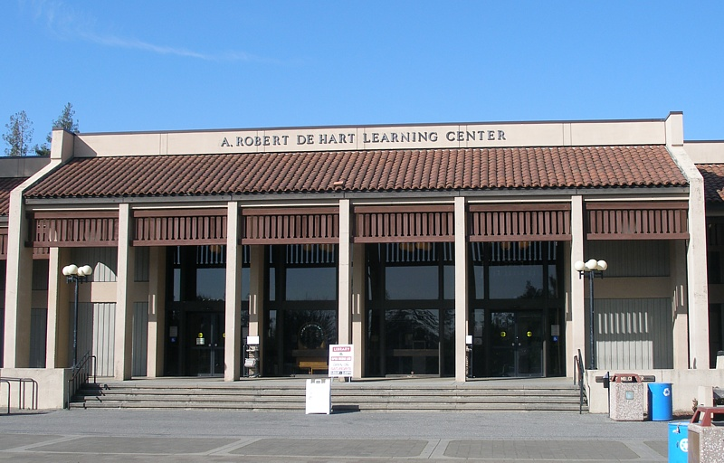

Coolcaesar, 2006 · [Wikimedia Commons](https://commons.wikimedia.org/wiki/File:Dehartlearningcenter.jpg), CC BY-SA 3.0.

### Cupertino, 2012

De Anza had cut more than **1,000 courses** and **8% of its faculty** since 2008.

Nearby Apple reported rising profits.

[Duhigg and Kocieniewski, NYT, April 28, 2012](https://www.nytimes.com/2012/04/29/business/apples-tax-strategy-aims-at-low-tax-states-and-nations.html)

Today: how firms reduce taxes, and what that means for the communities where they operate.

# A Brief Writing Exercise

## Your IB Voice

Question

Should Apple use every legal means available to minimize its tax bill? Address the strongest objection to your argument, considering Apple’s responsibilities to shareholders and the communities where it operates.

**10 minutes** · Individual · Notes permitted · No internet or LLMs

## Discuss your opening arguments

What is your strongest reason for or against Apple minimizing its taxes?

Listen to someone who disagrees. What concern does their argument raise for your position?

Class discussion

## Apple put investment income in Nevada

[figure not shown]

David Calvert / NYT, 2012 · [Syndicated report](https://www.livemint.com/Companies/lztyJbjJ29aP1ObdLsCOeM/How-Apple-sidesteps-billions-in-taxes.html).

### The 2012 arrangement

Apple’s subsidiary **Braeburn Capital** invested Apple’s cash.

Locating it in Nevada sheltered some investment income from California tax.

**Corporate tax rates in 2012:** California 8.84%; Nevada 0%.

This mechanism concerns state revenue. Apple’s overseas arrangements involve separate *national* tax systems.

## A factory and a tax home give countries a claim to profit

One company has its **tax home** in Germany, a factory branch in Poland, and customers in France.

[figure not shown]

Illustration of traditional treaty rules. [OECD Model Tax Convention, Articles 7 and 23](https://www.oecd.org/en/publications/model-tax-convention-on-income-and-on-capital-2017-full-version_g2g972ee-en.html)

Tax residence is the company’s legal home for tax purposes, often based on where it is registered or headquartered.

## MNCs Taxed Where Production Occurs

[figure not shown]

Original diagram excerpt: [Djankov, PIIE (2021)](https://www.piie.com/blogs/realtime-economics/2021/how-do-companies-avoid-paying-international-taxes), figure 1.

Country E is the customer market in this simplified model. Assume sales there create no taxable business presence.

## 1. Transfer pricing for physical products

A **transfer price** is a price between related companies.

[figure not shown]

Original diagram excerpt: [Djankov, PIIE (2021)](https://www.piie.com/blogs/realtime-economics/2021/how-do-companies-avoid-paying-international-taxes), figure 2a.

Low-tax Country D buys cheaply from Country C and sells at a high price to Country E.

## Internal prices affect MNC tax bills

[figure not shown]

|  | Internal price: $80 | Internal price: $70 |
| --- | --- | --- |
| Country C subsidiary profit, taxed at 30% | $20 | $10 |
| Country D subsidiary profit, taxed at 10% | $20 | $30 |
| **Total tax** | $6 + $2 = **$8** | $3 + $3 = **$6** |

Simplified example: the Country D subsidiary sells directly to the customer. Production cost and customer price stay fixed. Other costs and taxes are omitted.

The multinational still earns $40 before tax. Moving $10 of profit to the 10% country saves $2 in tax.

## Intangibles can earn income through royalties

Proprietary data, patents, software, and brands are **intangibles**: valuable assets without a physical form.

A **royalty** is a fee for permission to use them.

Unique data or **intellectual property (IP)** may have no comparable market transaction.

[figure not shown]

DeusXFlorida, 2008 · [Wikimedia Commons](https://commons.wikimedia.org/wiki/File:Coca-Cola_bottles.jpg), CC BY 2.0.

[OECD, hard-to-value intangibles guidance (2018)](https://www.oecd.org/content/dam/oecd/en/publications/reports/2018/06/guidance-for-tax-administrations-on-the-application-of-the-approach-to-hard-to-value-intangibles-beps-action-8_4cff0ba5/5e402215-en.pdf)

Without a reliable market price, royalties are harder to challenge and easier to use for shifting profit.

## 2. Royalties shift profit toward the IP owner

The company in Country D pays the IP owner in Country C for permission to use its IP.

[figure not shown]

Original diagram excerpt: [Djankov, PIIE (2021)](https://www.piie.com/blogs/realtime-economics/2021/how-do-companies-avoid-paying-international-taxes), figure 2b. The purple arrow shows the IP input; payment goes the other way.

## Google routed royalties through the Netherlands

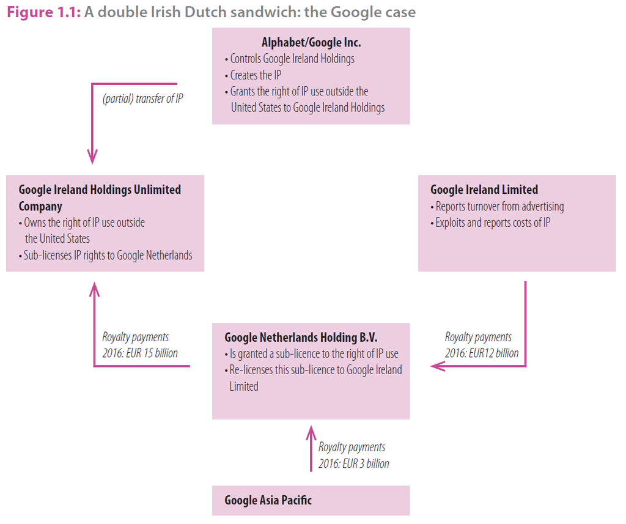

In **2016**, Google’s Irish advertising company paid **€12 billion** in royalties for the use of Google’s IP.

The Dutch affiliate passed those royalties, along with payments from Asia Pacific, to an Irish-incorporated IP holder managed in **Bermuda**.

[Eurostat](https://ec.europa.eu/eurostat/documents/3217494/9042238/KS-GP-18-001-EN-N.pdf/6964aace-99de-4558-a2ba-30f3a7b1bc3f)

## Another example

Cost sharing gave ASI economic rights to Apple’s IP for sales outside the Americas

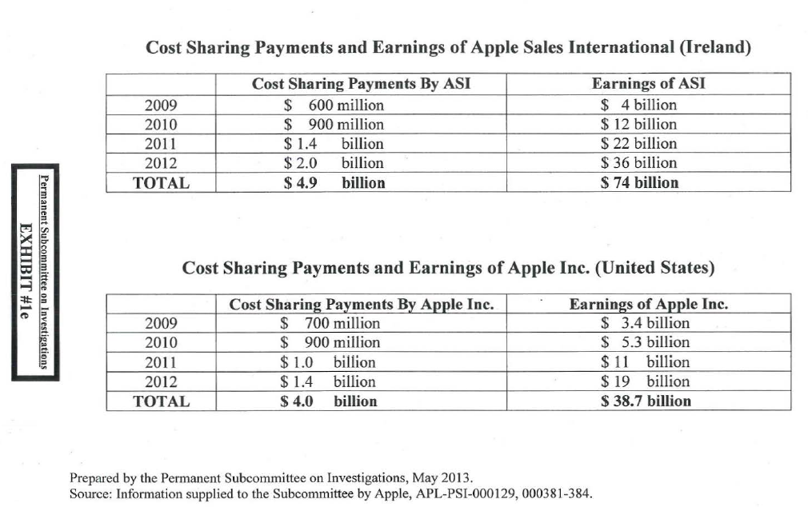

How much of the profit from a product developed largely in California should follow the affiliate that helped fund its development?

[U.S. Senate Investigation](https://www.hsgac.senate.gov/wp-content/uploads/imo/media/doc/EXHIBITS%201-19%20%28May%2021%202013%29.pdf)

## An online seller can reach customers without a local office

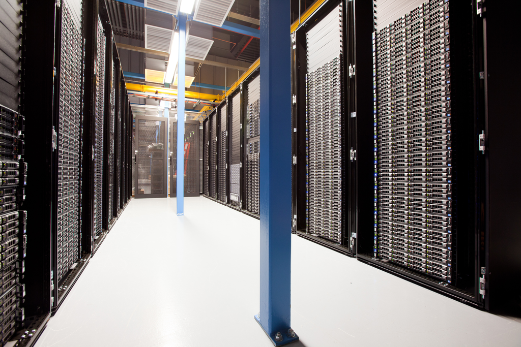

Helpameout, 2012 · [Wikimedia Commons](https://commons.wikimedia.org/wiki/File:Wikimedia_Servers-0051_19.jpg), CC BY-SA 3.0.

### Consider a streaming company

It sells subscriptions in Country E.

Traditional rules can leave Country E unable to tax its business profit.

Should Country E be able to tax some of the profit earned from its customers? Why?

## The IRS and Irish Revenue enforce transfer-pricing rules

### Who checks the tax return?

**U.S. Internal Revenue Service (IRS):** profits taxable in the United States.

**Irish Revenue:** profits taxable in Ireland.

Both can challenge internal product prices and royalties.

### Irish enforcement

€824m

from 55 completed transfer-pricing cases over the ten years to 2025

[Irish Revenue, Annual Report 2025, p. 56](https://www.revenue.ie/en/corporate/press-office/annual-report/2025/ar-2025.pdf). Reported yield includes €246m in interest and penalties.  
[IRS, transfer pricing](https://www.irs.gov/businesses/international-businesses/transfer-pricing).

**Arm’s-length pricing:** product prices and royalties should reflect terms independent companies would agree to.

## Tax avoidance

[figure not shown]

[Forbes](https://www.forbes.com/sites/tommybeer/2021/04/02/more-than-50-major-us-corporations-including-nike-and-fedex-paid-no-federal-taxes-last-year/)

# Governments respond

## The EU required Ireland to recover Apple’s tax benefits

### 2016: European Commission

Found that Ireland’s tax rulings gave Apple an **illegal advantage** over other companies.

Ordered Ireland to recover the tax benefits, plus interest.

### 2024: EU Court of Justice

Upheld the Commission’s decision after years of appeals.

€13bn

Approximate tax benefits to recover, before interest

[EU Court of Justice, September 10, 2024](https://curia.europa.eu/site/upload/docs/application/pdf/2024-09/cp240133en.pdf). Case concerned Irish tax rulings issued in 1991 and 2007.

Ireland appealed alongside Apple. The EU enforced rules against selective tax advantages granted by a member state.

## The OECD proposed a broader tax overhaul in 2020

[figure not shown]

[Financial Times, October 12, 2020](https://www.ft.com/content/c269d8ad-11d6-490a-b290-4d3dbf80bd03). Instructor-supplied clipping.

## The 2021 OECD/G20 agreement proposed two reforms

### Where companies pay

**Pillar One:** give customer countries a share of the largest, most profitable multinationals’ profits to tax.

This addresses sales in countries where the seller has little physical presence.

### How much companies pay

**Pillar Two:** set a **15% minimum tax** for large multinationals covered by the rules.

This reduces the reward for reporting profit in low-tax countries.

[OECD, proposed profit-allocation convention](https://www.oecd.org/en/topics/sub-issues/reallocation-of-taxing-rights-to-market-jurisdictions/multilateral-convention-to-implement-amount-a-of-pillar-one.html); [OECD, global minimum tax](https://www.oecd.org/en/topics/global-minimum-tax.html).

Governments agreed on the goals in 2021. Each part required further legal steps to take effect. In the U.S., Congressional approval was needed, but did not occur.

## U.S. withdrawal narrowed the global tax agreement

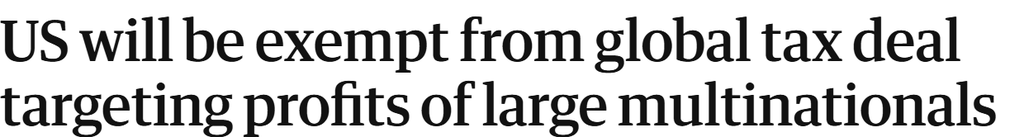

[The Guardian](https://www.theguardian.com/business/2026/jan/06/us-exemption-oecd-global-tax-deal-multinational-companies) · January 6, 2026. Headline excerpt.

The profit-allocation treaty is stalled. The minimum tax continues with a U.S. exception.

# Group discussion

## Calculate the tax bill for a product transaction

One parent owns a Country C subsidiary with an assembly plant and a Country D selling subsidiary. This example involves a **physical product**. There are no other costs or taxes.

### Country C subsidiary

Its assembly plant makes one product for **$50**.

Pays **30%** tax on its profit.

### Country D subsidiary

Buys the product from Country C and sells it to a customer for **$120**.

Pays **10%** tax on its profit.

Compare internal prices of **$80** and **$100**. Which price gives the multinational a lower tax bill, and why?

## Apply the royalty mechanism to your industry

Turn to the people near you. Each person names their industry and one kind of valuable IP it uses, such as software, a patent, or a brand. It’s fine if some of you have the same industry. Pick one example. Imagine a company in a low-tax country owns that IP and charges a related operating company a royalty to use it. What is the operating company paying for? If the royalty rises, where does reported profit go up, and where does it go down?